# Secondary Schools in Brighton & Hove

What the evidence says, and what it means for the city

Adam Dennett

Bartlett Centre for Advanced Spatial Analysis, UCL

Tuesday 29 September 2026

## Who am I?

- Professor of Urban Analytics at the Centre for Advanced Spatial Analysis, UCL
  - data, urban policy, quantitative methods, maps
- A former state secondary school teacher
- A Brighton resident, and a parent with a child at a city state school
- Everything tonight is built from **published data**, and all of it is open: the analysis, the code and a policy simulator you can try yourself

# What the evidence says

## A city whose schools do well

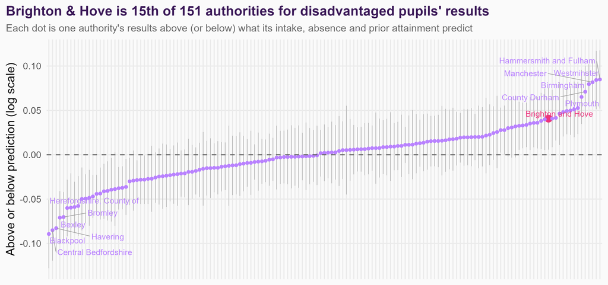

## A story of success, not failure

**Rank among 151 English authorities, after accounting for intake**

| Pupils | Rank |
| --- | --- |
| Disadvantaged | **15th** |
| Not disadvantaged | **4th** |
| All pupils | **5th** |

The 2024 admissions consultation started from a story of **failure**. The evidence says this is one of the **highest-performing** authorities in England once you account for who its schools teach.

The better question is not *“what is the city doing wrong?”* but *“what is it doing right, and what is holding it back?”*

## The problem is absence, not the mix of pupils

**Disadvantaged pupils** (the lever the council chose)

- City: 28.8% · England: 28.3%
- National percentile: **52th**
- *Unremarkable*

**Absence** (the lever left alone)

- City: 10.8% · England: 8.2%
- 2nd highest of 152 authorities
- **Among the worst in England**

Leave absence out of the model and the city ranks 69th for disadvantaged pupils rather than 15th. That difference, about **1.4 GCSE points per pupil**, is roughly what absence costs the city’s disadvantaged children.

## What causes differences in Attainment 8 between schools?

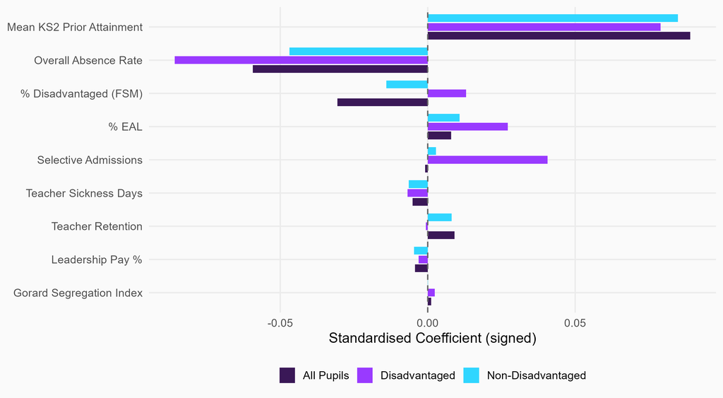

## How much can a school change?

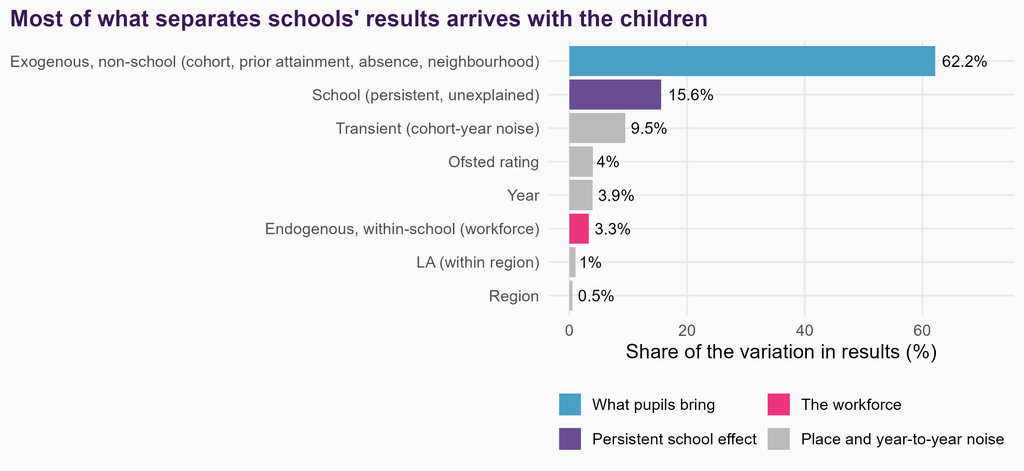

Moving a child to another building changes neither their attendance nor their circumstances. That is why redistribution is a weak instrument for raising results.

## Concentrated disadvantage: the counter-intuitive finding

Across England, after allowing for absence and prior attainment:

- **Not disadvantaged pupils** do a little worse in schools with more disadvantaged pupils
- **Disadvantaged pupils** do slightly **better**, not worse
- Consistent across years and different measures, and in line with the DfE’s own 2015 research
- The effect is small and runs mostly through **schools organised to serve those pupils**, not through concentration itself

This is **not** an argument for concentrating disadvantaged pupils.

It is an argument against assuming that deconcentration helps them, especially when it means longer journeys, and longer journeys mean more absence.

## BACA: the local example

**How it was seen**

- ‘Requires Improvement’ from Ofsted
- Among the city’s lowest headline results
- A catchment campaign for the right *not* to attend it

**What the data shows**

- About half its pupils are disadvantaged, with high absence and low prior attainment
- **The city’s strongest results for disadvantaged pupils**, once intake is accounted for

Disadvantaged pupils scored about **+5.7** GCSE points above comparable pupils in 2024–25, and **+3.1** on the four-year average.

April 2025: Ofsted rated it **Good** in every area. No surprise on the contextualised evidence.

A single year is noisy, so lean on the four-year figure. It is still far more than redistributing pupils could deliver.

## Families choose on the wrong number

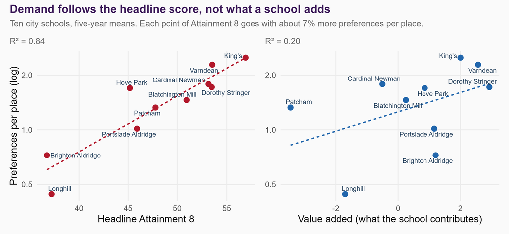

The council’s [secondary admissions guide](https://www.brighton-hove.gov.uk/schools-and-learning/school-policies-reports-strategies-and-other-documents/secondary-school-admissions-guide-2027-2028) tells parents to look at each school’s *“National Curriculum test results, public exam results”* and its Ofsted reports: figures that mostly describe who a school admits.

## A loop the council’s own advice sustains

```
flowchart LR
  A["Council guidance:<br/>look at exam results"] --> B["Families prefer schools<br/>with higher headline scores"]
  B --> C["Schools with more disadvantaged<br/>intakes are chosen less"]
  C --> D["Their intakes shrink and become<br/>more disadvantaged"]
  D --> E["Their headline scores fall"]
  E --> B
  C --> F["Smaller rolls, less funding,<br/>Longhill's viability at risk"]
  classDef key fill:#EEDEFF,stroke:#3A1857,color:#3A1857;
  classDef hit fill:#fdecd9,stroke:#d95f02,color:#3d1c00;
  class A key;
  class F hit;
```

BACA is **last of ten** on the raw Attainment 8 but **4th** on value added. It ranks **1st** for disadvantaged student value-added.

Objectively a great school - but parents choosing on raw attainment and it is losing out.

Changing the guidance, and publishing a contextualised measure beside the headline, would cost nothing.

## What if families read the other number?

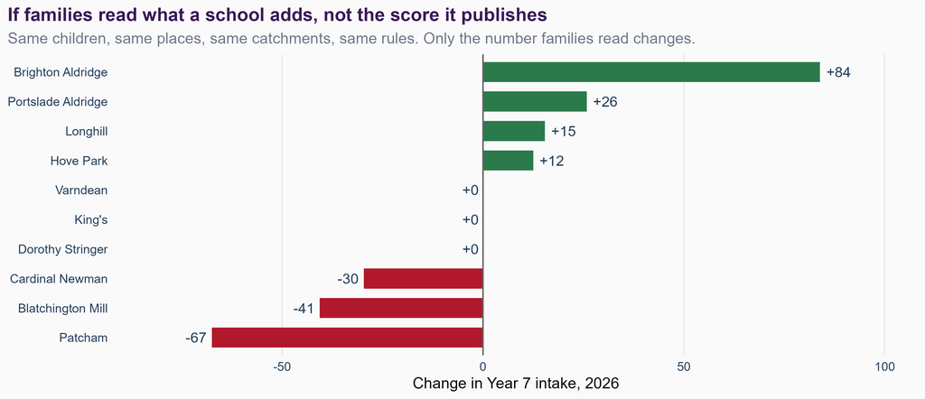

Brighton Aldridge goes from **91 children to 175** on 180 places — half empty to nearly full — without a boundary moving or a place being cut.

## The number that matters most

**Today, 93% of the city’s empty Year 7 places sit in just three schools.**

If families read value added, that falls to **75%**.

A surplus spread across ten schools is a **budgeting** problem.

A surplus piled into three is a **viability** problem — and that is the one Brighton & Hove actually has.

It creates no places and removes none. The city still has 299 empty Year 7 places either way. **What changes is which schools are empty.**

**Cost: nothing. Consultation needed: none.** The council writes the admissions guide.

**One assumption holds this up.** It takes families reading a contextualised measure as closely as they now read the headline score — a claim about publicity and persuasion, not a fitted number. The model shows what that would be worth if it worked, not that it would. And value added for a single school is noisy: Patcham’s fall rests on one four-year figure.

# The city’s schools

## A system built for more children than it has

**Longhill** takes about **90** children in 2026 on 210 places, and sits at the far eastern edge of the city.

But the money is **a city problem**, not only a Longhill problem.

## The cohort is already falling

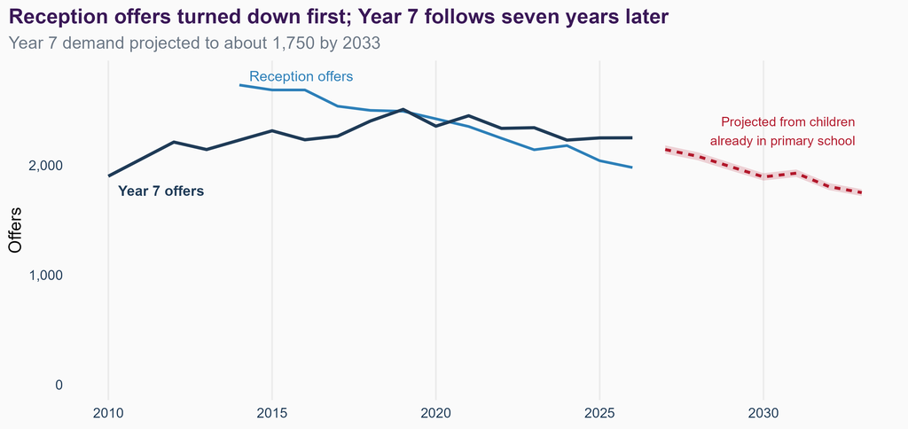

## Ten schools, and where the children live

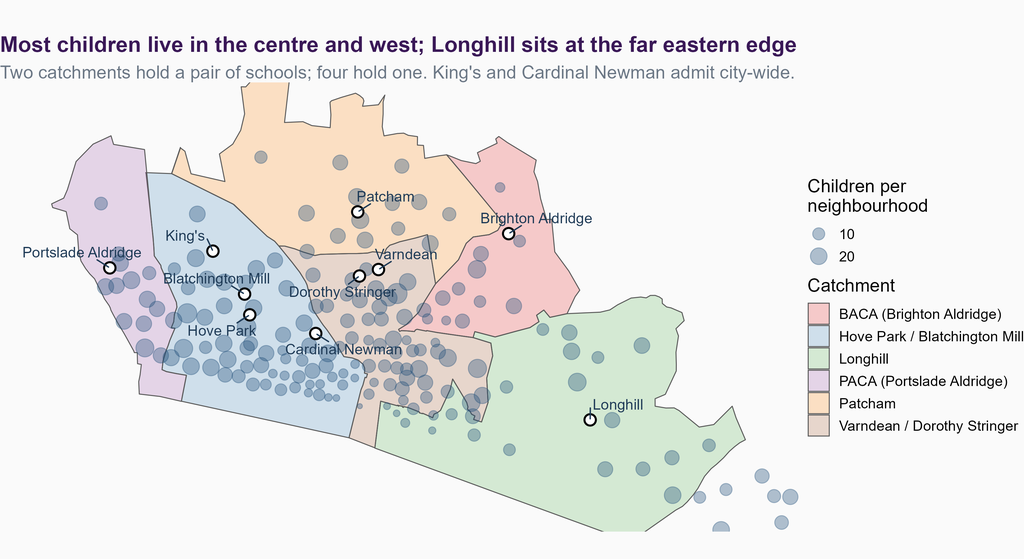

## Poor access and child poverty in the same places

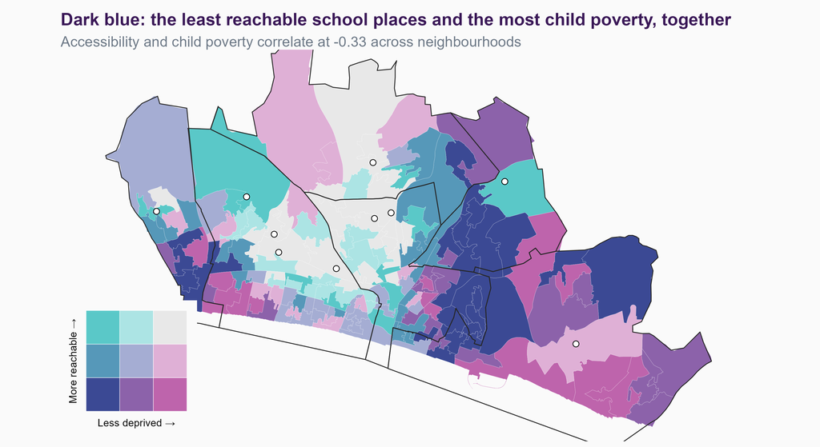

## Nine of ten schools are spending their reserves

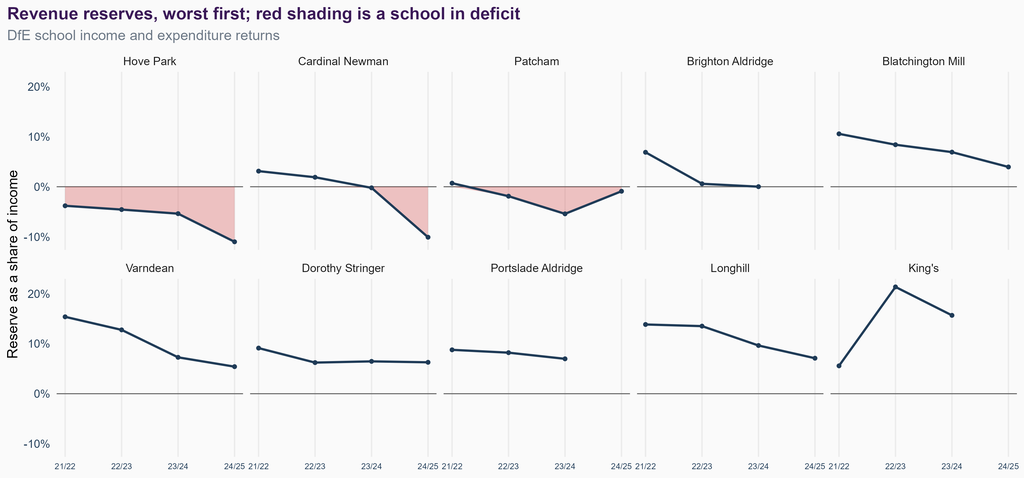

## What being in deficit means

- **7 of the ten** schools are maintained by the council, and **all 3** that are already overdrawn are among them
- A maintained school over **5% in deficit** must agree a recovery plan with the council, which cannot write the debt off
- If a struggling school becomes a **sponsored academy**, its deficit stays with the council, paid from its own budget
- Under pressure, schools cut teaching assistants, teachers and curriculum breadth, and pupils needing extra support lose most (Ofsted, *Making the cut*)

A recovery plan assumes the pressure is temporary. **A falling cohort is not.**

Taking places out only helps if the academies and faith schools share it: cutting only the council’s schools makes their budgets **worse**.

# What the model says about the options

## Brighton Secondary School System Simulator

[figure not shown]

Every option in this talk is a run of this — in a browser, no login, and [you can try your own](https://adamdennett-bh-school-system.share.connect.posit.cloud/).

## Why build a simulator?

**You can try a policy before you try it on children.**

In 2024 the city argued for months about options whose effects nobody — council, schools or parents — could see in advance. Decisions were taken on assertion, and trust was spent that has not come back.

A model does not settle what the city *should* want. It answers a narrower question: **if you did this, what would follow?** Journeys, intakes, the social mix, budgets, who gets displaced.

And it makes the trade-offs visible. Almost nothing here is free: every option that helps one thing costs another, and the argument is about which price is worth paying.

**It is accurate enough to be worth using.**

Modelled against the places the city’s schools actually offered for September 2026: **R² = 0.95**.

Against the council’s own count of pupils by home ward, from a source the model never saw: **correlation 0.96**.

It is fitted to what families *ask for*, not to the offers it is then tested against — so reproducing the offers is a check, not a circularity.

Every input is published data. Every line of code is open. If you think it is wrong, you can show where.

## A model of the whole city

```
flowchart LR
  d1["<b>Children</b><br/>census, postcodes,<br/>council projection"]
  d2["<b>Journeys</b><br/>walk and bus,<br/>routed"]
  d3["<b>What families ask for</b><br/>factsheets, catchment<br/>preference table"]
  d4["<b>Places and rules</b><br/>admission numbers,<br/>council priorities"]
  m["<b>Demand</b><br/>children shared by distance,<br/>attractiveness, catchment,<br/>competition"]
  c{"<b>Full?</b>"}
  p["<b>Priorities</b> decide<br/>who is admitted"]
  r["<b>Refused</b> re-offered:<br/>partner school,<br/>then 2nd preferences"]
  f["<b>Intakes</b> →<br/>journeys<br/>disadvantaged mix<br/>budgets"]
  s["<b>29 options<br/>× 3 years</b><br/>and the<br/>simulator"]
  d1 & d2 & d3 --> m --> c
  d4 --> c
  c -- yes --> p --> r --> c
  c -- no --> f --> s
  classDef data fill:#f3f5f8,stroke:#9aa7b4,color:#1f3b57;
  classDef run fill:#EEDEFF,stroke:#3A1857,color:#3A1857;
  classDef out fill:#edf6ef,stroke:#2b7a4b,color:#102a43;
  class d1,d2,d3,d4 data;
  class m,c,p,r run;
  class f,s out;
```

Every option tonight is a run of this model, built from published data and open to anyone to check or rerun.

## It reproduces the 2026 offers

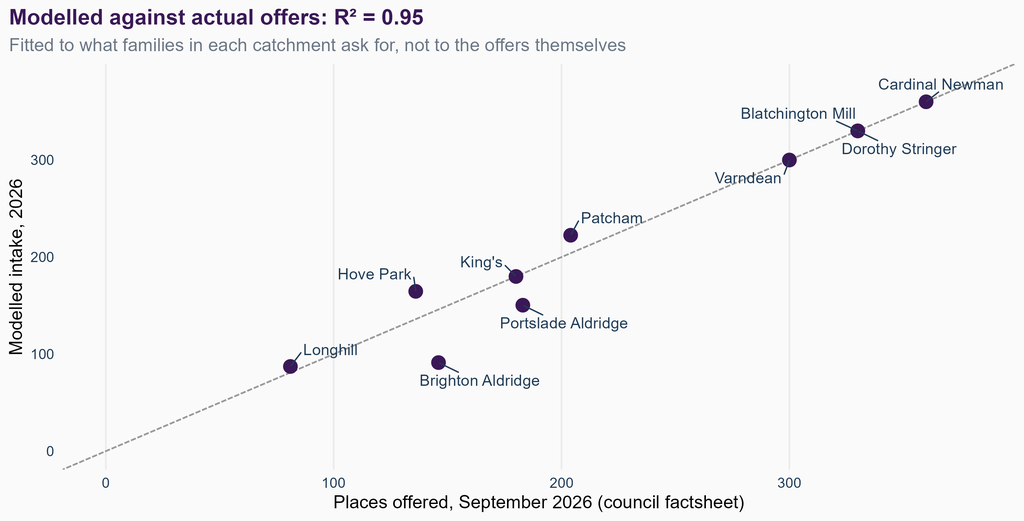

## Pull one lever, the effect shows up elsewhere

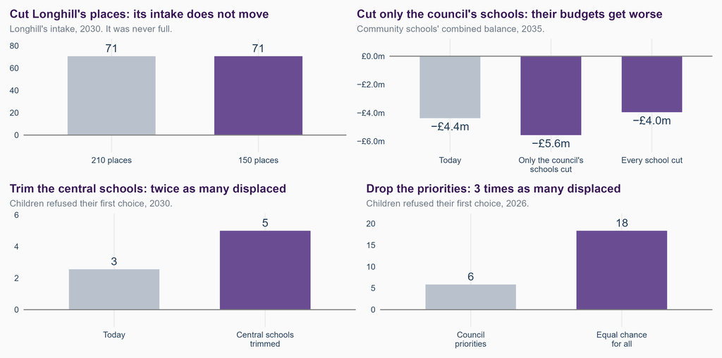

## Access or mixing? No option does both

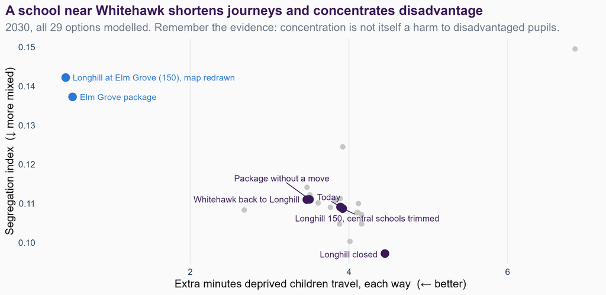

## A smaller Longhill at the top of Elm Grove

| Option | Longhill intake, 2026 → 2030 | Deprived children’s extra journey | Whitehawk’s disadvantaged children travel | Longhill’s annual position |
| --- | --- | --- | --- | --- |
| Today | 90 → 71 | 3.9 min | 56 min | −£0.8m |
| Elm Grove, 150 places, map redrawn | 106 → 86 | 0.4 min | 23 min | −£0.7m |
| Elm Grove package | 117 → 91 | 0.5 min | 22 min | −£0.7m |

**What it gains**

- The largest cut in deprived children’s journeys of any option
- Most of Whitehawk back in Longhill’s catchment, as part of a redesign
- More children for Longhill

**What it costs**

- A site, not yet costed; Longhill still does not break even
- Longer journeys for Rottingdean, Saltdean and Woodingdean
- It depends on families following a new map as closely as today’s

# What the city could do

## Priority one: attendance

The city has among the **worst absence in England** but **near-average disadvantage**. That is not inevitable, and it matters most for disadvantaged pupils.

Absence needs taking apart, because very different situations sit inside one statistic:

- a few days’ family holiday by an otherwise regular attender
- a child with special educational needs who struggles with the school environment
- a young carer with a long bus journey
- post-pandemic disengagement and mental health

Each needs a **different response**, and longer journeys push absence the wrong way.

## For admissions and places

1. **Change the admissions guidance** and publish a contextualised measure beside the headline score. It costs nothing, needs no consultation, and on the model it moves intakes further than any boundary change — and takes the share of empty places concentrated in three schools from 93% to 75%.
2. **Treat the bus network as an admissions instrument.** It widens real choice without taking anything from anyone.
3. **Plan places across the whole city.** The fall in pupils has to be shared, including by the academies and faith schools.
4. **Decide about Longhill on the financial timetable**, and test a smaller school at the top of Elm Grove properly, with costs stated.
5. **Don’t treat a more concentrated intake as a cost in itself.** Ask what serves disadvantaged pupils: attendance, journeys and well-organised schools.

## Better information for everyone

**The council already holds data that would settle most open questions**, for example:

- where applicants live, and their full preferences
- the criterion each place was given under, at every school
- children placed at a school they did not name
- offers to children living outside the city
- the catchment preference table, every year

**Release it in aggregate**, as the council already does with other small-area data.

With it, the ranges in this work become estimates, and the next decision can be tested **before** it is made rather than after.

## The final word

**The caution:** policy anchored to a single story, made in haste, risks doing more harm than good, especially to a system that is working well.

**The encouragement:** the raw materials for better policy already exist in published data, and so do tools to test options before they are chosen.

**The challenge:** getting that understanding to decision makers **before** decisions are made.

## Links and questions

**The report**

🔗 [How to Pull the Right Lever](https://adamdennett.github.io/school_attainment_tool/pulling_the_right_lever.html)

**The city system**

🔗 [A strategic view](https://adamdennett.github.io/bh-school-system/) · [The model, stage by stage](https://adamdennett.github.io/bh-school-system/model-guide.html)

**Try it yourself**

🔗 [School places simulator](https://adamdennett-bh-school-system.share.connect.posit.cloud/) · [Attainment policy simulator](https://adam-dennett.shinyapps.io/School_Attainment_Policy_Simulator/)

**Contact**

📧 a.dennett@ucl.ac.uk

All data used are published by the Department for Education, the council and other public bodies. All code is open source.

[figure not shown]